# Regular Expressions

Regular expressions are a powerful way to match patterns in text. These are nothing but trings with a special syntax and llow us to match paerns in other strings.

[figure not shown]

## Python's `re` Module

```python
import re
re.split('\s+', 'Split on spaces.')
```

```
['Split', 'on', 'spaces.']
```

# Tokenization

Tokenization is a process of Turning a string or document into tokens (smaller chunks). This is the first step in NLP. This can be done by different methods. However, the most common methods are:

- Breaking out words or sentences
- Separating punctuation
- Separating all hashtags in a tweet

## The `nltk` Module

`nltk` is a Python module that provides a variety of natural language processing (NLP) tools. Some of the most common methods included in the module are:

- `word_tokenize`: tokenizes a string into a list of words
- `sent_tokenize`: tokenizes a string into a list of sentences
- `regexp_tokenize` : tokenize a string or document based on aregular expression pattern
- `TweetTokenizer`: special class just for tweet tokenization, allowing you to separate hashtags, mentions and lots ofexclamation points!!!

```python
text = """
SCENE 1: [wind] [clop clop clop]
KING ARTHUR: Whoa there!  [clop clop clop]
SOLDIER #1: Halt!  Who goes there?
ARTHUR: It is I, Arthur, son of Uther Pendragon, from the castle of Camelot.  King of the Britons, defeator of the Saxons, sovereign of all England!
SOLDIER #1: Pull the other one!
ARTHUR: I am, ...  and this is my trusty servant Patsy.  We have ridden the length and breadth of the land in search of knights who will join me in my court at Camelot.  I must speak with your lord and master.
SOLDIER #1: What?  Ridden on a horse?
ARTHUR: Yes!
SOLDIER #1: You're using coconuts!
ARTHUR: What?
SOLDIER #1: You've got two empty halves of coconut and you're bangin' 'em together.
ARTHUR: So?  We have ridden since the snows of winter covered this land, through the kingdom of Mercea, through--
SOLDIER #1: Where'd you get the coconuts?
ARTHUR: We found them.
SOLDIER #1: Found them?  In Mercea?  The coconut's tropical!
ARTHUR: What do you mean?
SOLDIER #1: Well, this is a temperate zone.
ARTHUR: The swallow may fly south with the sun or the house martin or the plover may seek warmer climes in winter, yet these are not strangers to our land?
SOLDIER #1: Are you suggesting coconuts migrate?
ARTHUR: Not at all.  They could be carried.
SOLDIER #1: What?  A swallow carrying a coconut?
ARTHUR: It could grip it by the husk!
SOLDIER #1: It's not a question of where he grips it!  It's a simple question of weight ratios!  A five ounce bird could not carry a one pound coconut.
ARTHUR: Well, it doesn't matter.  Will you go and tell your master that Arthur from the Court of Camelot is here.
SOLDIER #1: Listen.  In order to maintain air-speed velocity, a swallow needs to beat its wings forty-three times every second, right?
ARTHUR: Please!
SOLDIER #1: Am I right?
ARTHUR: I'm not interested!
SOLDIER #2: It could be carried by an African swallow!
SOLDIER #1: Oh, yeah, an African swallow maybe, but not a European swallow.  That's my point.
SOLDIER #2: Oh, yeah, I agree with that.
ARTHUR: Will you ask your master if he wants to join my court at Camelot?!
SOLDIER #1: But then of course a-- African swallows are non-migratory.
SOLDIER #2: Oh, yeah...
SOLDIER #1: So they couldn't bring a coconut back anyway...  [clop clop clop]
SOLDIER #2: Wait a minute!  Supposing two swallows carried it together?
SOLDIER #1: No, they'd have to have it on a line.
SOLDIER #2: Well, simple!  They'd just use a strand of creeper!
SOLDIER #1: What, held under the dorsal guiding feathers?
SOLDIER #2: Well, why not?
"""
```

```python
# Import necessary modules
from nltk.tokenize import sent_tokenize, word_tokenize

# Split scene_one into sentences: sentences
sentences = sent_tokenize(text)

# Use word_tokenize to tokenize the fourth sentence: tokenized_sent
tokenized_sent = word_tokenize(sentences[3])

# Make a set of unique tokens in the entire scene: unique_tokens
unique_tokens = set(word_tokenize(text))

# Print the unique tokens result
print(unique_tokens)
```

[output not shown]

## Regex with NLTK tokenization

`nltk` provides a `regexp_tokenize` method that can be used to tokenize a string based on a regular expression pattern. Simply use `regexp_tokenize(string, pattern)`with `string` and `pattern`.

```python
from nltk.tokenize import regexp_tokenize
my_string = "SOLDIER #1: Found them? In Mercea? The coconut's tropical!"
pattern = r"(\w+|#\d|\?|!)"
regexp_tokenize(my_string, pattern)
```

```
['SOLDIER',
 '#1',
 'Found',
 'them',
 '?',
 'In',
 'Mercea',
 '?',
 'The',
 'coconut',
 's',
 'tropical',
 '!']
```

Twitter is a frequently used source for NLP text and tasks. The `regexp.tokenize.TweetTokenizer` class gives you some extra methods and attributes for parsing tweets.

Unlike the syntax for the regex library, with `regexp_tokenize()` you pass the pattern as the second argument.

```python
tweets = ['This is the best #nlp exercise ive found online! #python', '#NLP is super fun! <3 #learning', 'Thanks @datacamp :) #nlp #python']
```

```python
from nltk.tokenize import regexp_tokenize, TweetTokenizer

pattern1 = r"#\w+"
hashtags = regexp_tokenize(tweets[0], pattern1)
print(hashtags)

pattern2 = r"([@#]\w+)"
mentions_hashtags = regexp_tokenize(tweets[-1], pattern2)
print(mentions_hashtags)
```

```
['#nlp', '#python']
['@datacamp', '#nlp', '#python']
```

```python
tknzr = TweetTokenizer()
all_tokens = [tknzr.tokenize(text = t) for t in tweets]
all_tokens
```

```
[['This',
  'is',
  'the',
  'best',
  '#nlp',
  'exercise',
  'ive',
  'found',
  'online',
  '!',
  '#python'],
 ['#NLP', 'is', 'super', 'fun', '!', '<3', '#learning'],
 ['Thanks', '@datacamp', ':)', '#nlp', '#python']]
```

### Non-ascii tokenization

```python
german_text = 'Wann gehen wir Pizza essen? 🍕 Und fährst du mit Über? 🚕'
```

```python
# Tokenize and print all words in german_text
all_words = word_tokenize(german_text)
print(all_words)

# Tokenize and print only capital words
capital_words = r"[A-ZÜ]\w+"
print(regexp_tokenize(german_text, capital_words))

# Tokenize and print only emoji
emoji = "['\U0001F300-\U0001F5FF'|'\U0001F600-\U0001F64F'|'\U0001F680-\U0001F6FF'|'\u2600-\u26FF\u2700-\u27BF']"
print(regexp_tokenize(german_text, emoji))
```

```
['Wann', 'gehen', 'wir', 'Pizza', 'essen', '?', '🍕', 'Und', 'fährst', 'du', 'mit', 'Über', '?', '🚕']
['Wann', 'Pizza', 'Und', 'Über']
['🍕', '🚕']
```

## Charting word length with NLTK

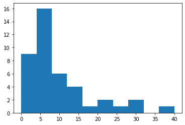

```python
import matplotlib.pyplot as plt
# Split the script into lines: lines
lines = text.split('\n')

# Replace all script lines for speaker
pattern = "[A-Z]{2,}(\s)?(#\d)?([A-Z]{2,})?:"
lines = [re.sub(pattern, '', l) for l in lines]

# Tokenize each line: tokenized_lines
tokenized_lines = [regexp_tokenize(s, r"\w+") for s in lines]

# Make a frequency list of lengths: line_num_words
line_num_words = [len(t_line) for t_line in tokenized_lines]

# Plot a histogram of the line lengths
plt.hist(line_num_words);
```